# 3.2. Environments

In RStudio, you might have noticed that you have a pane called **Environment**_. As you create objects in R, they show up in that pane. So what are environments?

You can think of environments as a collection of name value pairs (called a frame) together with an enclosure, itself another environment. The names are symbols. So it is really a nesting of frames.

In an interactive session, you are in the global environment `.GlobalEnv`, which you can print.

```r
.GlobalEnv
```

```
## <environment: R_GlobalEnv>
```

You can list all objects in your global environment using `ls()` or `objects()`.

```r
ls()
```

```
##  [1] "catn"                       "coxSampleSize"
##  [3] "f"                          "genPasswd"
##  [5] "getBioc"                    "install_if_needed"
##  [7] "installIfNeeded"            "l1"
##  [9] "l2"                         "myself"
## [11] "myself_at_r"                "reinstall_my_packages"
## [13] "save_my_installed_packages" "update_all_my_packages"
## [15] "x"                          "y"
## [17] "z"
```

```r
objects()
```

```
##  [1] "catn"                       "coxSampleSize"
##  [3] "f"                          "genPasswd"
##  [5] "getBioc"                    "install_if_needed"
##  [7] "installIfNeeded"            "l1"
##  [9] "l2"                         "myself"
## [11] "myself_at_r"                "reinstall_my_packages"
## [13] "save_my_installed_packages" "update_all_my_packages"
## [15] "x"                          "y"
## [17] "z"
```

A comment on the *dot* naming convention. This is usually used in R to name things that you don’t want to expose to everyone. Like hidden files in Unix.

Looking up a name/symbol involves searching for it in the sequence of frames, proceding up the enclosing environments all the way to the top root, an empty environment.

An object is un-addressable if it is not bound to a name in an accessible environment. In fact, R will trash such an object when it sees fit as part of *garbage collection*.

```r
is.environment(.GlobalEnv)
```

```
## [1] TRUE
```

```r
globalenv()
```

```
## <environment: R_GlobalEnv>
```

```r
environment() ## current environment
```

```
## <environment: R_GlobalEnv>
```

Note that nothing stops you from renaming `.GlobalEnv`, although peculiar.

```r
.GlobalEnv <- "foobar"
.GlobalEnv
```

```
## [1] "foobar"
```

```r
ls(.GlobalEnv)
```

```
## Error in as.environment(pos): no item called "foobar" on the search list
```

However, it is still there and can be accessed via the function `globalenv()`.

```r
ls(globalenv())
```

```
##  [1] "catn"                       "coxSampleSize"
##  [3] "f"                          "genPasswd"
##  [5] "getBioc"                    "install_if_needed"
##  [7] "installIfNeeded"            "l1"
##  [9] "l2"                         "myself"
## [11] "myself_at_r"                "reinstall_my_packages"
## [13] "save_my_installed_packages" "update_all_my_packages"
## [15] "x"                          "y"
## [17] "z"
```

(Here, you see what is in *my* global environment. Your environment, of course, will have different things.)

This is one reason why it is bad practice to use things like `.GlobalEnv` in your code directly rather than using accessor functions like `globalenv()`.

# 3.2.1. Creating and Assigning in Environments

Environments can be created using the function `new.env`. Note that the default enclosing environment is the place where you are defining the environment.

```r
e1 <- new.env()
e1
```

```
## <environment: 0x7f7f8e4d59c8>
```

What’s in the frame of `e1`?

```r
ls(e1)
```

```
## character(0)
```

There are several ways to assign objects in environments:

1. Using the list style

```r
e1[["a"]] <- 1  ## list style assigment
ls(e1)
```

```
## [1] "a"
```

2. Using the `assign` function

```r
assign("b", 2, envir = e1) ## using assign function
ls(e1)
```

```
## [1] "a" "b"
```

3. Using the `$` syntax, like lists again.

```r
e1$x <- runif(10)  ## dollar style assignment
ls.str(e1)  ## ls.str prints more usefully
```

```
## a :  num 1
## b :  num 2
## x :  num [1:10] 0.9732 0.2456 0.6304 0.0845 0.2398 ...
```

You can also use list style syntax for retrieving values in environments.

```r
get(x = "a", pos = e1)  ## get "a" from e1
```

```
## [1] 1
```

```r
get(x = "a", envir = e1)
```

```
## [1] 1
```

```r
e1$b
```

```
## [1] 2
```

```r
e1[["x"]] ## list style
```

```
##  [1] 0.97316979 0.24561695 0.63044629 0.08452376 0.23978303 0.66458365
##  [7] 0.49578642 0.50689951 0.73621423 0.94739132
```

However, you have to be aware that `$` and `[[` look only in the environment and return `NULL` for unbound variables, but `get` behaves differently, as we will soon see below.

To check whether an object exists, use use `exists`.

```r
exists("x", envir = e1)
```

```
## [1] TRUE
```

To remove objects, you can use `rm`.

```r
x <- 1:10
rm("x", envir = e1)  ## blow away x in e1
```

That merely removed the object `x` from the environment `e1`.

Let us now try to retrieve `x`.

```r
e1$x
```

[output not shown]

That makes sense. But

```r
get("x", e1) ## Huh?
```

```
##  [1]  1  2  3  4  5  6  7  8  9 10
```

The `get` function has an argument `inherits` which is `TRUE` by default, causing it to search for objects that might be in enclosing environments. (Recall the nested structure of environments!)

```r
get("x", e1, inherits = FALSE) ## Ok
```

```
## Error in get("x", e1, inherits = FALSE): object 'x' not found
```

Sometimes, you really do want the environment to have `inherits=FALSE` behavior, by default. In that case, you can do the following.

```r
e2 <- new.env(parent = emptyenv())
e2$foo <- "a"
get("foo", e2)
```

```
## [1] "a"
```

```r
get("bar", e2)
```

```
## Error in get("bar", e2): object 'bar' not found
```

Nothing can be assigned into the empty environment. Try.

To summarize, an environment is similar to a named list, with four important exceptions:

- Every name must be unique.
- The names in an environment are not ordered.
- An environment has a parent.
- Environments are not copied when modified. (more on this later)

# 3.2.2. Search paths

Most environments are created by R for you automatically. For example, each package you use using `library()` becomes one of the parents of the global environment.

The function `search` will list all the attached packages, that is, those that have been added to the search path.

```r
search()
```

```
##  [1] ".GlobalEnv"        "package:lobstr"    "ESSR"
##  [4] "package:stats"     "package:graphics"  "package:grDevices"
##  [7] "package:datasets"  "package:rmarkdown" "package:knitr"
## [10] "package:pkgdown"   "package:devtools"  "package:usethis"
## [13] "package:utils"     "package:methods"   "Autoloads"
## [16] "package:base"
```

Pictoral representation (source: Wickham’s *Advanced R*) showing parents.

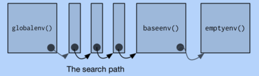

Note the effect of adding a library. First, before loading a library.

```r
search()
```

```
##  [1] ".GlobalEnv"        "package:lobstr"    "ESSR"
##  [4] "package:stats"     "package:graphics"  "package:grDevices"
##  [7] "package:datasets"  "package:rmarkdown" "package:knitr"
## [10] "package:pkgdown"   "package:devtools"  "package:usethis"
## [13] "package:utils"     "package:methods"   "Autoloads"
## [16] "package:base"
```

Next, after loading a library.

```r
library(ggplot2, quietly = TRUE)
search()
```

```
##  [1] ".GlobalEnv"        "package:ggplot2"   "package:lobstr"
##  [4] "ESSR"              "package:stats"     "package:graphics"
##  [7] "package:grDevices" "package:datasets"  "package:rmarkdown"
## [10] "package:knitr"     "package:pkgdown"   "package:devtools"
## [13] "package:usethis"   "package:utils"     "package:methods"
## [16] "Autoloads"         "package:base"
```

The function `searchpaths` returns a character vector pointing to the actual (file) path used to load the code.

```r
searchpaths()
```

```
##  [1] ".GlobalEnv"
##  [2] "/usr/local/lib/R/3.6/site-library/ggplot2"
##  [3] "/usr/local/lib/R/3.6/site-library/lobstr"
##  [4] "ESSR"
##  [5] "/usr/local/Cellar/r/3.6.2/lib/R/library/stats"
##  [6] "/usr/local/Cellar/r/3.6.2/lib/R/library/graphics"
##  [7] "/usr/local/Cellar/r/3.6.2/lib/R/library/grDevices"
##  [8] "/usr/local/Cellar/r/3.6.2/lib/R/library/datasets"
##  [9] "/usr/local/lib/R/3.6/site-library/rmarkdown"
## [10] "/usr/local/lib/R/3.6/site-library/knitr"
## [11] "/usr/local/lib/R/3.6/site-library/pkgdown"
## [12] "/usr/local/lib/R/3.6/site-library/devtools"
## [13] "/usr/local/lib/R/3.6/site-library/usethis"
## [14] "/usr/local/Cellar/r/3.6.2/lib/R/library/utils"
## [15] "/usr/local/Cellar/r/3.6.2/lib/R/library/methods"
## [16] "Autoloads"
## [17] "/usr/local/Cellar/r/3.6.2/lib/R/library/base"
```

The order of the environments listed in `search()` determines how R locates objects. And you can list out the order explicity via:

```r
e <- environment() ## current env
while (TRUE) {
    e <- parent.env(e)  ## parent env.
    print(e)
}
```

```
## <environment: package:ggplot2>
## attr(,"name")
## [1] "package:ggplot2"
## attr(,"path")
## [1] "/usr/local/lib/R/3.6/site-library/ggplot2"
## <environment: package:lobstr>
## attr(,"name")
## [1] "package:lobstr"
## attr(,"path")
## [1] "/usr/local/lib/R/3.6/site-library/lobstr"
## <environment: 0x7f7f8cdf5c70>
## attr(,"name")
## [1] "ESSR"
## <environment: package:stats>
## attr(,"name")
## [1] "package:stats"
## attr(,"path")
## [1] "/usr/local/Cellar/r/3.6.2/lib/R/library/stats"
## <environment: package:graphics>
## attr(,"name")
## [1] "package:graphics"
## attr(,"path")
## [1] "/usr/local/Cellar/r/3.6.2/lib/R/library/graphics"
## <environment: package:grDevices>
## attr(,"name")
## [1] "package:grDevices"
## attr(,"path")
## [1] "/usr/local/Cellar/r/3.6.2/lib/R/library/grDevices"
## <environment: package:datasets>
## attr(,"name")
## [1] "package:datasets"
## attr(,"path")
## [1] "/usr/local/Cellar/r/3.6.2/lib/R/library/datasets"
## <environment: package:rmarkdown>
## attr(,"name")
## [1] "package:rmarkdown"
## attr(,"path")
## [1] "/usr/local/lib/R/3.6/site-library/rmarkdown"
## <environment: package:knitr>
## attr(,"name")
```

[output cut: 18 more lines]

```
## <environment: package:utils>
## attr(,"name")
## [1] "package:utils"
## attr(,"path")
## [1] "/usr/local/Cellar/r/3.6.2/lib/R/library/utils"
## <environment: package:methods>
## attr(,"name")
## [1] "package:methods"
## attr(,"path")
## [1] "/usr/local/Cellar/r/3.6.2/lib/R/library/methods"
## <environment: 0x7f7f890c63c8>
## attr(,"name")
## [1] "Autoloads"
## <environment: base>
## <environment: R_EmptyEnv>
```

```
## Error in parent.env(e): the empty environment has no parent
```

You are free to modify the search paths using commands such as `attach` or `detach` but there are restrictions: detaching the workspace in position 1 or the base package will cause an error.

However, I frown upon this unless done in a disciplined manner.

For example, I’ve seen many scripts that do the following. Consider the `mtcars` data set that is built into R.

```r
str(mtcars)
```

```
## 'data.frame':    32 obs. of  11 variables:
##  $ mpg : num  21 21 22.8 21.4 18.7 18.1 14.3 24.4 22.8 19.2 ...
##  $ cyl : num  6 6 4 6 8 6 8 4 4 6 ...
##  $ disp: num  160 160 108 258 360 ...
##  $ hp  : num  110 110 93 110 175 105 245 62 95 123 ...
##  $ drat: num  3.9 3.9 3.85 3.08 3.15 2.76 3.21 3.69 3.92 3.92 ...
##  $ wt  : num  2.62 2.88 2.32 3.21 3.44 ...
##  $ qsec: num  16.5 17 18.6 19.4 17 ...
##  $ vs  : num  0 0 1 1 0 1 0 1 1 1 ...
##  $ am  : num  1 1 1 0 0 0 0 0 0 0 ...
##  $ gear: num  4 4 4 3 3 3 3 4 4 4 ...
##  $ carb: num  4 4 1 1 2 1 4 2 2 4 ...
```

They would like to use the variables `mpg`, `cyl`, `hp` etc. in code without having to type `mtcars$mpg`, `mtcars$cyl`, `mtcars$hp` etc. Say, just for the sake of argument, a linear fit

```r
lm(disp ~ mpg)
```

```
## Error in eval(predvars, data, env): object 'disp' not found
```

which will fail for now, instead of

```r
lm(mtcars$disp ~ mtcars$mpg)
```

```
##
## Call:
## lm(formula = mtcars$disp ~ mtcars$mpg)
##
## Coefficients:
## (Intercept)   mtcars$mpg
##      580.88       -17.43
```

So an easy way to make this possible is to `attach` the `mtcars` data frame as an environment!

```r
attach(mtcars)
```

which now changes the search path.

```r
search()
```

```
##  [1] ".GlobalEnv"        "mtcars"            "package:ggplot2"
##  [4] "package:lobstr"    "ESSR"              "package:stats"
##  [7] "package:graphics"  "package:grDevices" "package:datasets"
## [10] "package:rmarkdown" "package:knitr"     "package:pkgdown"
## [13] "package:devtools"  "package:usethis"   "package:utils"
## [16] "package:methods"   "Autoloads"         "package:base"
```

So the following now works.

```r
lm(disp ~ mpg)
```

```
##
## Call:
## lm(formula = disp ~ mpg)
##
## Coefficients:
## (Intercept)          mpg
##      580.88       -17.43
```

But you better be prepared to `detach` the data frame to restore the search path else you can have unpredictable behavior.

```r
detach(mtcars)
```

The key issue is that such code modifies a *global* variable, the search path, which is not good practice, because it can produce unpredictable behavior, something that a functional style of programming tries to avoid.